# Project: Investigating TMDb movie dataset

- Introduction
- Data Wrangling
- Exploratory Data Analysis
- Conclusions

## Introduction

The movie business is an interesting one, and every commercial movie's main goal is to turn a profit. I will be looking at the TMDb movie dataset for my investigation. This data collection includes details on 10,000 movies that were gathered from The Movie Database (TMDb), including genre and revenue information that will serve as the foundation for this investigation. some questions have been asked and will be answered using the following tools:

- python
- matplotlib
- numpy

### Question to be answered

- Which genres are the most popular year after year?
- Is there a link between popularity and high-profit films?
- Which months have the highest film profits?
- Which actor has the most movie popularity and profit?
- How does the length of a film effect its profit?

```python
# Upgrade pandas to use dataframe.explode() function.
!pip install --upgrade pandas
!pip install --upgrade matplotlib
```

```python
#import the necessary libraries to be used
import pandas as pd
import matplotlib.pyplot as plt
%matplotlib inline
import numpy as np
plt.style.use('seaborn')
```

## Data Wrangling

now we need to load the data set and perform the necessary cleaning processes in preparation for analysis.

### General Properties

```python
#Load the data in a dataframe
df_movies = pd.read_csv('tmdb-movies.csv')

#print out a few lines of the data
df_movies.head(2)
```

|  | id | imdb_id | popularity | budget | revenue | original_title | cast | homepage | director | tagline | ... | overview | runtime | genres | production_companies | release_date | vote_count | vote_average | release_year | budget_adj | revenue_adj |
| --- | --- | --- | --- | --- | --- | --- | --- | --- | --- | --- | --- | --- | --- | --- | --- | --- | --- | --- | --- | --- | --- |
| 0 | 135397 | tt0369610 | 32.985763 | 150000000 | 1513528810 | Jurassic World | Chris Pratt\|Bryce Dallas Howard\|Irrfan Khan\|Vi... | http://www.jurassicworld.com/ | Colin Trevorrow | The park is open. | ... | Twenty-two years after the events of Jurassic ... | 124 | Action\|Adventure\|Science Fiction\|Thriller | Universal Studios\|Amblin Entertainment\|Legenda... | 6/9/15 | 5562 | 6.5 | 2015 | 1.379999e+08 | 1.392446e+09 |
| 1 | 76341 | tt1392190 | 28.419936 | 150000000 | 378436354 | Mad Max: Fury Road | Tom Hardy\|Charlize Theron\|Hugh Keays-Byrne\|Nic... | http://www.madmaxmovie.com/ | George Miller | What a Lovely Day. | ... | An apocalyptic story set in the furthest reach... | 120 | Action\|Adventure\|Science Fiction\|Thriller | Village Roadshow Pictures\|Kennedy Miller Produ... | 5/13/15 | 6185 | 7.1 | 2015 | 1.379999e+08 | 3.481613e+08 |

2 rows × 21 columns

Execute operations to inspect the kinds of the data and check for instances of missing or potentially incorrect data.

```python
df_movies.shape
```

```
(10866, 21)
```

```python
df_movies.describe()
```

|  | id | popularity | budget | revenue | runtime | vote_count | vote_average | release_year | budget_adj | revenue_adj |
| --- | --- | --- | --- | --- | --- | --- | --- | --- | --- | --- |
| count | 10866.000000 | 10866.000000 | 1.086600e+04 | 1.086600e+04 | 10866.000000 | 10866.000000 | 10866.000000 | 10866.000000 | 1.086600e+04 | 1.086600e+04 |
| mean | 66064.177434 | 0.646441 | 1.462570e+07 | 3.982332e+07 | 102.070863 | 217.389748 | 5.974922 | 2001.322658 | 1.755104e+07 | 5.136436e+07 |
| std | 92130.136561 | 1.000185 | 3.091321e+07 | 1.170035e+08 | 31.381405 | 575.619058 | 0.935142 | 12.812941 | 3.430616e+07 | 1.446325e+08 |
| min | 5.000000 | 0.000065 | 0.000000e+00 | 0.000000e+00 | 0.000000 | 10.000000 | 1.500000 | 1960.000000 | 0.000000e+00 | 0.000000e+00 |
| 25% | 10596.250000 | 0.207583 | 0.000000e+00 | 0.000000e+00 | 90.000000 | 17.000000 | 5.400000 | 1995.000000 | 0.000000e+00 | 0.000000e+00 |
| 50% | 20669.000000 | 0.383856 | 0.000000e+00 | 0.000000e+00 | 99.000000 | 38.000000 | 6.000000 | 2006.000000 | 0.000000e+00 | 0.000000e+00 |
| 75% | 75610.000000 | 0.713817 | 1.500000e+07 | 2.400000e+07 | 111.000000 | 145.750000 | 6.600000 | 2011.000000 | 2.085325e+07 | 3.369710e+07 |
| max | 417859.000000 | 32.985763 | 4.250000e+08 | 2.781506e+09 | 900.000000 | 9767.000000 | 9.200000 | 2015.000000 | 4.250000e+08 | 2.827124e+09 |

```python
df_movies.info()
```

```
<class 'pandas.core.frame.DataFrame'>
RangeIndex: 10866 entries, 0 to 10865
Data columns (total 21 columns):
 #   Column                Non-Null Count  Dtype
---  ------                --------------  -----
 0   id                    10866 non-null  int64
 1   imdb_id               10856 non-null  object
 2   popularity            10866 non-null  float64
 3   budget                10866 non-null  int64
 4   revenue               10866 non-null  int64
 5   original_title        10866 non-null  object
 6   cast                  10790 non-null  object
 7   homepage              2936 non-null   object
 8   director              10822 non-null  object
 9   tagline               8042 non-null   object
 10  keywords              9373 non-null   object
 11  overview              10862 non-null  object
 12  runtime               10866 non-null  int64
 13  genres                10843 non-null  object
 14  production_companies  9836 non-null   object
 15  release_date          10866 non-null  object
 16  vote_count            10866 non-null  int64
 17  vote_average          10866 non-null  float64
 18  release_year          10866 non-null  int64
 19  budget_adj            10866 non-null  float64
 20  revenue_adj           10866 non-null  float64
dtypes: float64(4), int64(6), object(11)
memory usage: 1.7+ MB
```

Check dataframe for duplicate

```python
print('the total sum of duplicate values in the dataframe is',df_movies.duplicated().sum())
```

```
the total sum of duplicate values in the dataframe is 1
```

**My Finding**

We can see the shape, description, and information for each column in our dataset here, and there are some interesting things to highlight.

The dataset has 10866 rows and 21 columns; there appear to be some missing values in nearly half of the columns; the homepage column has 7930 missing values, followed by the tagline column with 2824.

According to the dataframe's description, almost half of the budget and revenue columns contain the value $0 (assuming the values are in dollars), which I believe is missing data. A couple movies have 0 minutes and one has 900 minutes, which appears to be an error. A movie's average runtime is 102 minutes.

About 50% of the movies are with the years 2006-2015 and the relese_date data type should be in datetime format.

columns to drop are `homepage, id, imdb_id, tagline, keywords, overview, budget_adj, revenue_adj, vote_count, vote_average.`

> **note**: The vote count and vote average columns should be removed because inconsistency in the vote count affects the integrity of the vote average, which is dependent on the vote count. *i.e A vote total of only ten people rating a film at 8.0 is not a strong indicator of quality.*

### Data Cleaning

Raw data is usually dirty and must be thoroughly cleaned before analysis can begin. We reviewed the dataset and will now proceed to clean it.

Drop duplicted rows

```python
df_movies.drop_duplicates(inplace=True)
```

Remove unwanted columns

```python
#list of columns to drop
columns_to_drop = ['homepage','id','imdb_id','tagline','keywords','overview','budget_adj','production_companies','revenue_adj','vote_count','vote_average']

#remove all columns in the list and make the change permanent
df_movies.drop(columns_to_drop,axis=1,inplace=True)
```

Remove all $0 value from the budget and revenue column

```python
#query to check for a values in the budget and revenue columns that are not $0
df_movies_edit = df_movies.query('budget !=0 & revenue != 0')
#to return a copy of the df so any changes will not affect the orignal df
df_movies_edit = df_movies_edit.copy()
```

Check for any other null values

```python
#check for the total amount of null values if any
df_movies_edit.isnull().sum()
```

```
popularity        0
budget            0
revenue           0
original_title    0
cast              4
director          1
runtime           0
genres            0
release_date      0
release_year      0
dtype: int64
```

Drop the null values in the edited data set

```python
df_movies_edit.dropna(inplace=True)
```

Reset the index of the df_movies_edit dataframe

```python
#reset the index, drop the index column and make the change permanant
df_movies_edit.reset_index(drop=True,inplace=True)
```

Change the release_year datatype from object to datetime

```python
#split the date by '/' and store in the variable called date
date = df_movies_edit.release_date.str.split('/')
#loop through each date and change the format
for i,j in enumerate(date):
    j[2] = df_movies_edit.release_year[i]
    date[i] = "{}/{}/{}".format(j[0],j[1],j[2])

#change the datatype to datetimen64
df_movies_edit.release_date = date.astype('datetime64')
```

checking if the datatypes are in the format we want

```python
df_movies_edit.dtypes
```

```
popularity               float64
budget                     int64
revenue                    int64
original_title            object
cast                      object
director                  object
runtime                    int64
genres                    object
release_date      datetime64[ns]
release_year               int64
dtype: object
```

```python
#final shape of the dataset
df_movies_edit.shape
```

```
(3849, 10)
```

## Exploratory Data Analysis

```python
#This function will create all vertical barplots that apply the groupby function.

def bar_plot_groupby(group_by, column, func, title=None, xlabel=None, ylabel=None, ticks=None, labels=None, figsize=None):
    """
    groupby argument takes the column the dataframe should be grouped by
    the column argument takes the name of the column to be used
    the title argument returns the title of the plot
    and func is the function you want to perform on the column, which can either be 'count', np.mean, np.sum
    other arguments that can be used are xlabel, ylabel, ticks and labels for the x-axis
    """
    if func == 'count':
        df_plot = df_movies_edit.groupby(group_by)[column].count()
    else:
        df_plot = df_movies_edit.groupby(group_by)[column].agg(func)
    df_plot.plot(kind='bar',fontsize=13, xlabel=xlabel, ylabel=ylabel, figsize=figsize)
    plt.xticks(rotation=45)
    if ticks != None and labels!= None:
        plt.xticks(ticks=ticks,labels=labels, rotation='horizontal')
    plt.title(title,fontsize=14)
```

### Research Question 1: Which genres are the most popular year after year?

```python
#initalize the variables used to hold the result
year_genre = []
df_year_genre = []
```

```python
#store the range of years in the year variable
year = [range(df_movies_edit.release_year.min(),df_movies_edit.release_year.max()+1)]
#loop through each year and split the genre into individual components
for i in range(df_movies_edit.release_year.min(),df_movies_edit.release_year.max()+1):
    df_new = df_movies_edit.query('release_year == {}'.format(i))
    genre = df_new.genres.str.split('|')
    dic_genre = {}
    for j in genre:
        for x in j:
            keys = dic_genre.keys()
            if x in keys:
                dic_genre[x] += 1
            else:
                dic_genre[x] = 1

    df_year_genre.append(dic_genre)
    #return the genre with the maximum number of movies
    maximum = max(dic_genre, key= dic_genre.get)
    year_genre.append([i,maximum])
    dic_genre["year"] = i
```

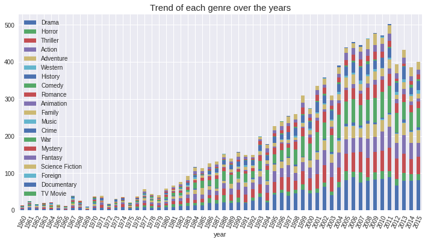

```python
#plot a stacked bar chart to show the total amount of movies and the genre
df_year_genre = pd.DataFrame(df_year_genre)
df_year_genre.set_index('year',inplace=True)
df_year_genre.plot(kind='bar', stacked=True, figsize=(12,6));
plt.xticks(rotation=65);
plt.title('Trend of each genre over the years',fontsize=15);
```

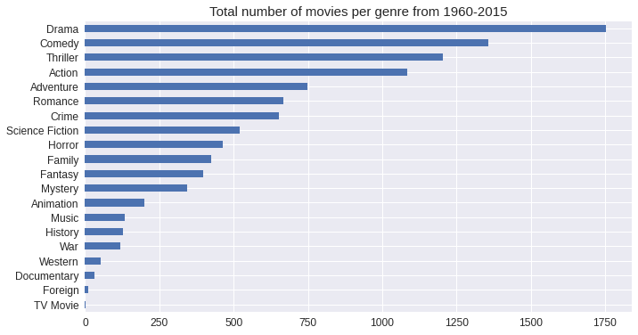

```python
#a plot of the cummulative sum of each genre from 1960 to 20150
df_year_genre.fillna(0).cumsum(axis=0,skipna=True).iloc[-1].sort_values(ascending=True).plot(kind='barh',figsize=(11,6),fontsize=12);
plt.title('Total number of movies per genre from 1960-2015',fontsize=15);
```

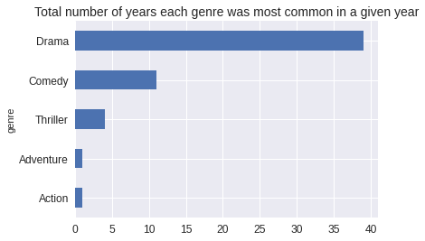

```python
df_tot = pd.DataFrame(year_genre,columns=['year','genre'])
df_tot.genre = df_tot.genre.astype('category')
df_tot.groupby('genre')['year'].count().sort_values().plot(kind='barh',fontsize=12)
plt.title('Total number of years each genre was most common in a given year',fontsize=14);
```

Based on the plots above, the drama genre produces the most movies year after year, followed by the comedy genre, and thrillers come in third.

### Research Question 2: Is there a link between popularity and high-profit films?

Create profit column, which is the difference between the budget and revenue

```python
#create a profit in USD column
df_movies_edit['profit_in_USD'] = df_movies_edit.revenue - df_movies_edit.budget
df_movies_edit.profit_in_USD.describe()
```

```
count    3.849000e+03
mean     7.056595e+07
std      1.506990e+08
min     -4.139124e+08
25%     -1.312284e+06
50%      2.014450e+07
75%      8.198066e+07
max      2.544506e+09
Name: profit_in_USD, dtype: float64
```

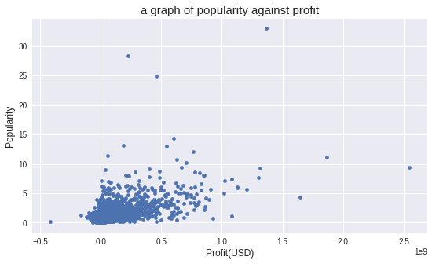

```python
df_movies_edit.plot(kind='scatter',x='profit_in_USD',y='popularity',figsize=(9,5));
plt.title('a graph of popularity against profit',fontsize=15);
plt.ylabel('Popularity',fontsize=12);
plt.xlabel('Profit(USD)',fontsize=12);
```

This simple scatterplot shows that there is a positive correlation between a movie's popularity and its profit.

**note**: *not every popular movie is profitable and this is as a result of lurking varibles and is beyond the scope of this research*

### Research Question 3: Which months have the highest film profits?

```python
df_movies_edit['month'] = [i.month for i in df_movies_edit.release_date]
```

```python
ticks = range(12)
labels = ['Jan','Feb','March','April','May','June','July','Aug','Sept','Oct','Nov','Dec']
```

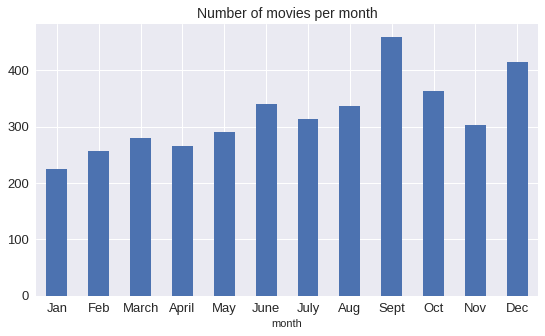

```python
bar_plot_groupby('month','month','count',title='Number of movies per month',ticks=ticks,labels=labels,figsize=(9,5))
```

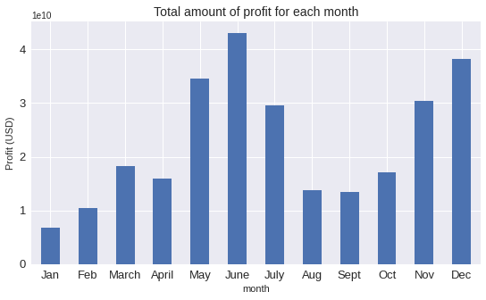

```python
bar_plot_groupby('month','profit_in_USD',np.sum,title='Total amount of profit for each month',ticks=ticks,labels=labels,ylabel='Profit (USD)',figsize=(9,5))
```

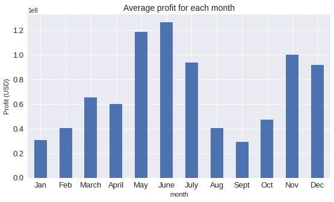

```python
bar_plot_groupby('month','profit_in_USD',np.mean,title='Average profit for each month',ticks=ticks,labels=labels,ylabel='Profit (USD)',figsize=(9,5))
```

From the graphs above, the most movies are released in September, followed by December, October, and June respectively, although this does not always imply that better movies are released in these months.

### Research Question 4: Which actor has the most movie popularity and profit?

```python
cast = df_movies_edit.cast.str.split('|')
dic = {}
for i in cast:
    for x in i:
        keys = dic.keys()
        if x in keys:
            dic[x] += 1
        else:
            dic[x] = 1
top_25_actors = sorted(dic, key=dic.get, reverse=True)[:25]
```

```python
actor_list = []
for i in top_25_actors:
    file = df_movies_edit.cast.str.contains(i)
    new = df_movies_edit[file]
    avg_profit = new['profit_in_USD'].sum()/new.shape[0]
    avg_pop = new['popularity'].sum()/new.shape[0]
    actor_list.append([i,avg_pop,avg_profit])
df_actors = pd.DataFrame(actor_list,columns=['actor','avg_pop','avg_profit'])
df_actors.set_index('actor',inplace=True)
```

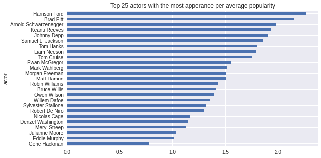

```python
df_actors['avg_pop'].sort_values().plot(kind='barh',figsize=(9,5))
plt.title('Top 25 actors with the most apperance per average popularity');
```

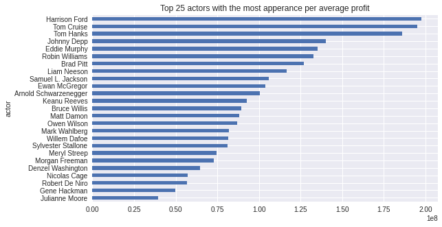

```python
df_actors['avg_profit'].sort_values().plot(kind='barh',figsize=(9,5))
plt.title('Top 25 actors with the most apperance per average profit');
```

### Research Question 5: How does the length of a film effect its profit?

the graph below is a scatter plot of profit in USD againt runtime, it doesn't give enough information about the relationship between them

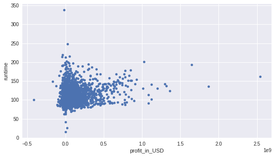

```python
df_movies_edit.plot(kind='scatter',x='profit_in_USD',y='runtime',figsize=(9,5));
```

Using the cut method, divide the runtime into several groups and study each one.

```python
#cut the runtime column in various groups
df_movies_edit['runtime_category'] = pd.cut(df_movies_edit['runtime'],bins=[0,60,90,120,150,180,240,338])
```

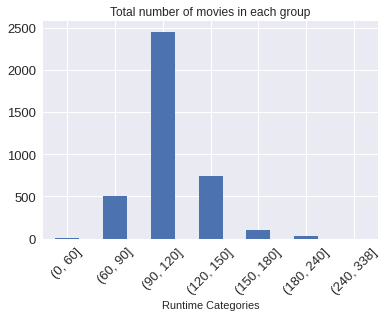

```python
bar_plot_groupby('runtime_category', 'original_title', title='Total number of movies in each group', func='count', xlabel='Runtime Categories')
df_movies_edit.groupby('runtime_category')['original_title'].count().plot(kind='bar',fontsize=13)
plt.xticks(rotation=45)
plt.title('Total number of movies in each group')
plt.xlabel('Runtime Categories');
```

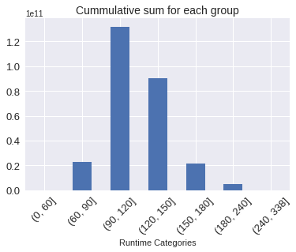

```python
bar_plot_groupby('runtime_category', 'profit_in_USD', title='Cummulative sum for each group', func=np.sum, xlabel='Runtime Categories')
```

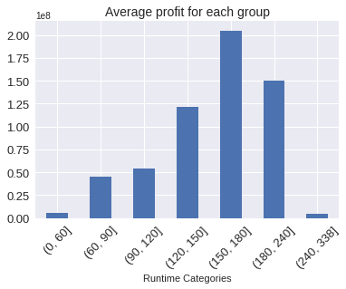

```python
bar_plot_groupby('runtime_category', 'profit_in_USD', title='Average profit for each group', func=np.mean, xlabel='Runtime Categories')
```

## Conclusions

The following are the findings of the research:

**Limitations**:

- Due to null values a lot of rows were dropped
- zero values in the budget and revenue columns

```python
from subprocess import call
call(['python', '-m', 'nbconvert', 'Investigate_a_Dataset.ipynb'])
```

```
0
```